# Reproducible Research Assigment 1

Lisa van der Heijden

18-7-2019

# Peer feedback assignment 1

## Assigment

This assignment will be described in multiple parts. You will need to write a report that answers the questions detailed below. Ultimately, you will need to complete the entire assignment in a single R markdown document that can be processed by knitr and be transformed into an HTML file.

Throughout your report make sure you always include the code that you used to generate the output you present. When writing code chunks in the R markdown document, always use echo = TRUE so that someone else will be able to read the code. This assignment will be evaluated via peer assessment so it is essential that your peer evaluators be able to review the code for your analysis.

For the plotting aspects of this assignment, feel free to use any plotting system in R (i.e., base, lattice, ggplot2)

Fork/clone the GitHub repository created for this assignment. You will submit this assignment by pushing your completed files into your forked repository on GitHub. The assignment submission will consist of the URL to your GitHub repository and the SHA-1 commit ID for your repository state.

NOTE: The GitHub repository also contains the dataset for the assignment so you do not have to download the data separately.

## Loading and preprocessing the data

The following code chunk will empty the global environment. This will make sure that vectors won’t be overwriten or confused with one another.

```r
rm(list = ls())
```

The next step is to set the working directory.

```r
wd <- "~/Documents/datasciencecourse/course 5/week 2"
setwd(wd)
```

Continuing with the assignment, the data will be read.

```r
dat <- read.csv("activity.csv", sep =",", header = TRUE)
```

The following code will give some information about the dataset

```r
dim(dat) #Show the dimensions of the dataset
```

```
## [1] 17568     3
```

```r
names(dat) #Returns the column names of the dataset
```

```
## [1] "steps"    "date"     "interval"
```

```r
head(dat) #Shows the first couple of rows of the dataset
```

```
##   steps       date interval
## 1    NA 2012-10-01        0
## 2    NA 2012-10-01        5
## 3    NA 2012-10-01       10
## 4    NA 2012-10-01       15
## 5    NA 2012-10-01       20
## 6    NA 2012-10-01       25
```

```r
summary(dat, na.rm = TRUE) #Returns a 5 number summary and the mean of each column
```

```
##      steps                date          interval
##  Min.   :  0.00   2012-10-01:  288   Min.   :   0.0
##  1st Qu.:  0.00   2012-10-02:  288   1st Qu.: 588.8
##  Median :  0.00   2012-10-03:  288   Median :1177.5
##  Mean   : 37.38   2012-10-04:  288   Mean   :1177.5
##  3rd Qu.: 12.00   2012-10-05:  288   3rd Qu.:1766.2
##  Max.   :806.00   2012-10-06:  288   Max.   :2355.0
##  NA's   :2304     (Other)   :15840
```

## First question: What is the mean total number of steps taken per day?

Next, the total number of steps per day needs to be calculated.

```r
library(dplyr) #Load the dplyr package
sumofsteps <- dat %>% group_by(date) %>% summarise(sum = sum(steps, na.rm = TRUE))
```

The following code will make a histogram of the total number of steps taken per day.

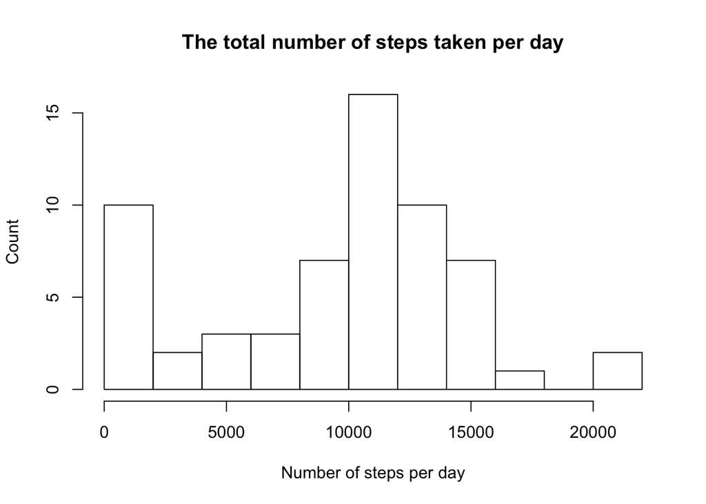

```r
hist(sumofsteps$sum, breaks = 8,
     xlab = "Number of steps per day", ylab = "Count", main = "The total number of steps taken per day")
```

The following code will calculate the mean and median of the total steps taken per day.

```r
meansteps <- mean(sumofsteps$sum, na.rm=TRUE)
mediansteps <- median(sumofsteps$sum, na.rm = TRUE)
```

The mean of the total number of steps per day is 9354.2295082. The median of the total number of steps per day is 10395.

## Second question: What is the average daily activity pattern?

The visualise the average daily activity pattern, the mean number of steps per time interval must be calculated.

```r
dailyactivity <- dat %>% group_by(interval) %>% summarise(mean = mean(steps, na.rm = TRUE))
```

Next code chunk will present the code to make the plot

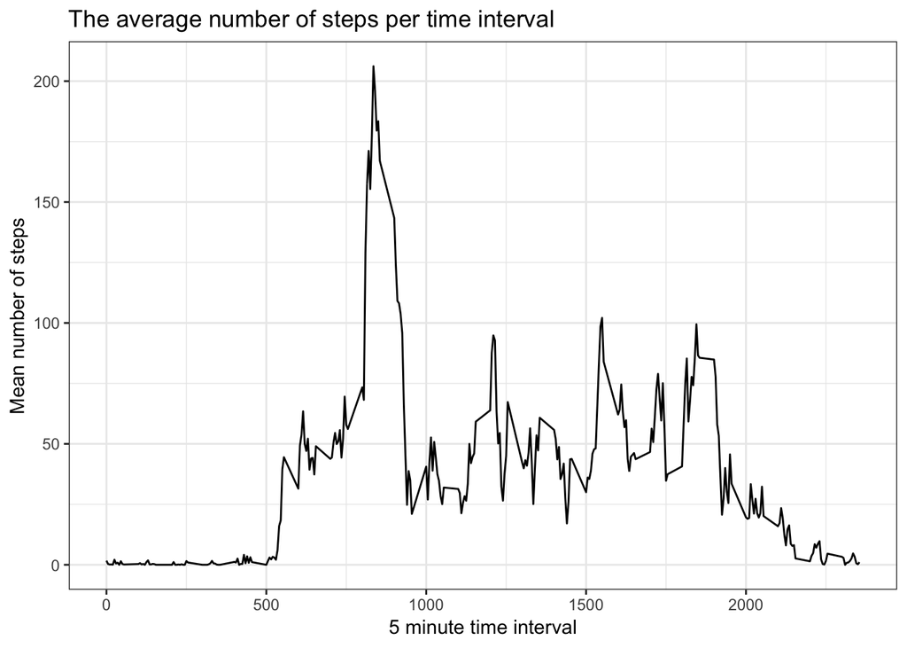

```r
library(ggplot2)
ggplot(data = dailyactivity, aes(x = interval, y = mean))+
        geom_line()+
        xlab("5 minute time interval")+
        ylab("Mean number of steps")+
        ggtitle("The average number of steps per time interval")+
        theme_bw()
```

The following code finds the interval with the maximum of the average of taken steps per time interval.

```r
interval <- dailyactivity$interval[dailyactivity$mean == max(dailyactivity$mean, na.rm = TRUE)]
```

Interval 835 has on average across all the days in the data, the maximum number of steps.

## Third question: Imputing missing values

```r
missingvalues <- sum(is.na(dat))
```

The total number of missing values is 2304.

The missing values will be imputed with the mean value of the interval

```r
nonNadat <- dat %>%
        group_by(interval) %>%
        mutate(steps = ifelse(is.na(steps),
                                 mean(steps, na.rm = TRUE),
                                 steps)
               )
```

The following code will make a histogram of the total number of steps taken each day. And it will calculate the mean and median of the total number of steps taken per day.

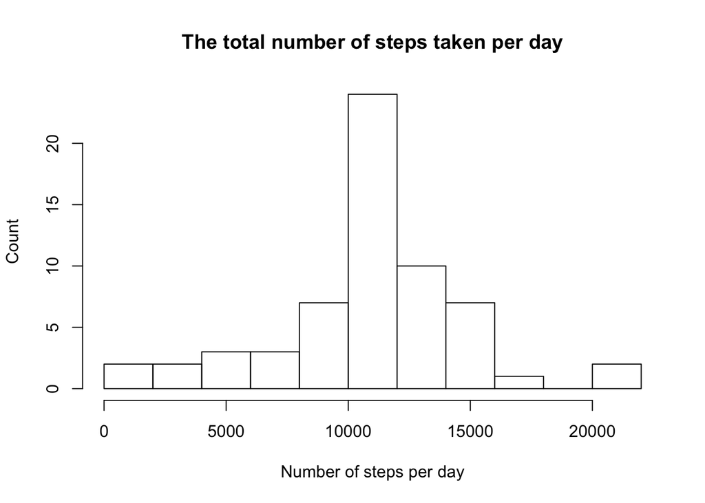

```r
nonNAtotalsteps <- nonNadat %>%
        group_by(date) %>%
        summarise(total = sum(steps))

hist(nonNAtotalsteps$total, breaks = 8,
     xlab = "Number of steps per day", ylab = "Count", main = "The total number of steps taken per day")
```

```r
nonNAmeansteps <- mean(sumofsteps$sum, na.rm=TRUE)
nonNAmediansteps <- median(sumofsteps$sum, na.rm = TRUE)
```

## Fourth question: Are there differences in activity patterns between weekdays and weekends

The following code creates a new variable in the dataset with two levels: “weekdays” and “weekend” indicating whether a given data is a weekday or weekend day.

```r
dates <- as.character(nonNadat$date)
dates <- as.Date(dates, format = "%Y-%m-%d")
```

```r
days <- weekdays(dates)
weekendays <- c("Saturday", "Sunday")
weekorweekend <- ifelse(days == "Saturday", "Weekend", ifelse(
                days == "Sunday", "Weekend",
                "Weekday")
        )
```

```r
nonNadat$weekend <- weekorweekend
```

The following code will create a plot containing time series plot (i.e. type = “l”“) of the 5-minute interval (x-axis) and the average number of steps taken, averaged across all weekday days or weekend days (y-axis).

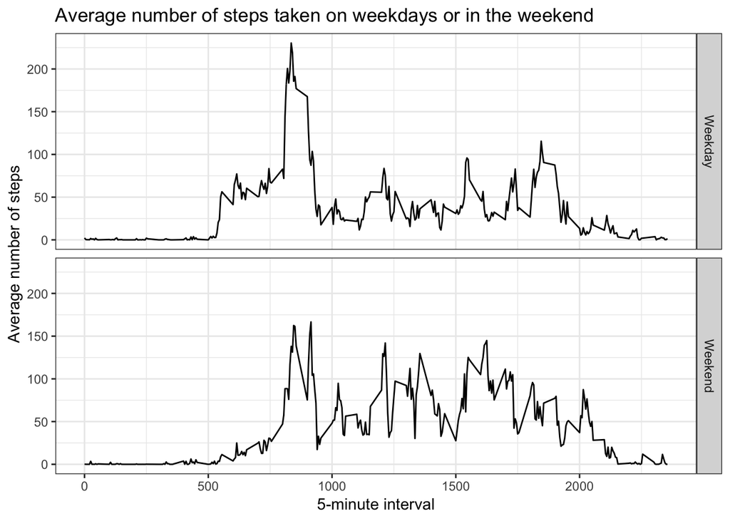

```r
datperweekend <- nonNadat %>%
                group_by(weekend, interval) %>%
                summarise(average = mean(steps)) #Calculate the mean number of steps per interval and weekdays or weekendays

ggplot(data  = datperweekend, aes(x = interval, y = average))+
        geom_line()+
        facet_grid(weekend ~ .)+
        xlab("5-minute interval")+
        ylab("Average number of steps")+
        ggtitle("Average number of steps taken on weekdays or in the weekend")+
        theme_bw()
```